# Souvenir Sales - Time Series Analysis

The following is a statistical analysis on a monthly time series which collects data about the sales of a souvenir shop in Australia in the period between 1987 and 1992.

The analysis will roughly follow the Box-Jenkins method and will focus on reaching stationarity for the time series, estimating a SARIMA model and predicting future values.

## Data exploration

```python
import numpy as np
import pandas as pd
import matplotlib.pyplot as plt
import seaborn as sns
from statsmodels.graphics.tsaplots import plot_acf, plot_pacf
from statsmodels.tsa.stattools import adfuller, kpss
from scipy.stats import boxcox
from scipy.special import inv_boxcox
import pmdarima as pm
import warnings
warnings.filterwarnings("ignore")
```

```python
tseries = pd.read_csv("data/monthly_sales_queensland.csv", header = 0, parse_dates = ["date"], index_col = 0)
```

```
Now that we have imported the time series, let's have a first look at its values.
```

```python
tseries
```

| date | sales |
| --- | --- |
| 1987-01-01 | 1664.81 |
| 1987-02-01 | 2397.53 |
| 1987-03-01 | 2840.71 |
| 1987-04-01 | 3547.29 |
| 1987-05-01 | 3752.96 |
| ... | ... |
| 1992-08-01 | 19888.61 |
| 1992-09-01 | 23933.38 |
| 1992-10-01 | 25391.35 |
| 1992-11-01 | 36024.80 |
| 1992-12-01 | 80721.71 |

72 rows × 1 columns

```python
tseries.index.min(), tseries.index.max()
```

```
(Timestamp('1987-01-01 00:00:00'), Timestamp('1992-12-01 00:00:00'))
```

```python
tseries.index.max() - tseries.index.min()
```

```
Timedelta('2161 days 00:00:00')
```

## Check for non-stationarity

Let's make a plot and see what we can say about it.

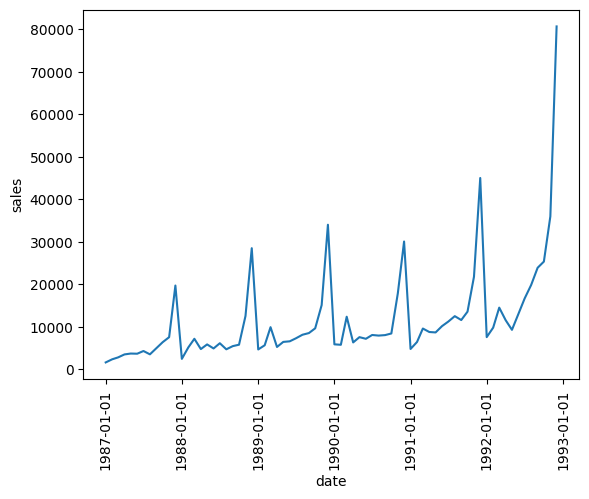

```python
fig, ax = plt.subplots()
ax.plot(tseries["sales"])
ax.set_xlabel("date")
ax.set_ylabel("sales")
ax.set_xticks(ax.get_xticks()[1::1])
plt.xticks(rotation = 90)
plt.show()
```

From the plot of the series, we can already grasp that it is not stationary, as the expected value is not constant over time and neither is variance, which tends to increase. In particular, we can speculate the presence of an upward trend and a seasonal effect, which is comprehensible, considering the tourist vocation of the shop.

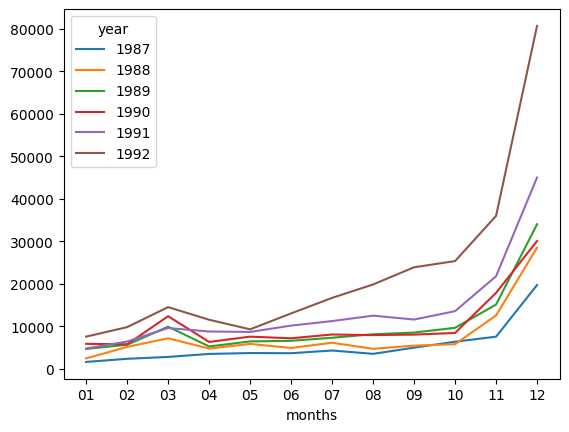

```python
df_years = tseries.copy(deep = True)
df_years.reset_index(inplace = True)
df_years["year"] = pd.to_datetime(df_years["date"]).dt.year
df_years["date"] = pd.to_datetime(df_years["date"]).dt.strftime("%m")
unstacked = df_years.set_index(["year", "date"])["sales"].unstack(-2)
unstacked.plot(xlabel = "months", xticks = pd.Series(range(0,12)))
```

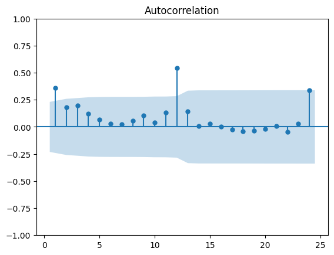

```python
plot_acf(tseries["sales"], lags = 24, zero = False);
```

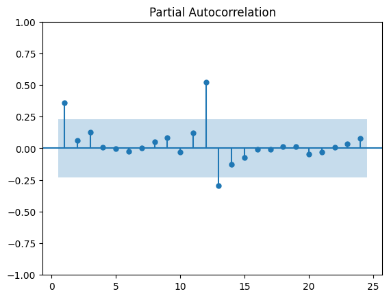

```python
plot_pacf(tseries["sales"], lags = 24, zero = False, method = "ywm");
```

Lastly, these are the *global* and *partial autocorrelation functions* for the series. The slow decay for the ACF suggests, once again, the existence of a trend, while the spikes at lag 12 indicate a probable seasonality.

To formalize our guesses, let's resort to two statistical test:

- The **Augmented Dickey-Fuller test** tests the null hypothesis of the presence of a unit root in our time series
- The **KPSS test** tests the null hypothesis that our data is stationary

```python
adfuller(tseries["sales"])
```

```
(2.4588875832659216,
 0.9990353814133549,
 12,
 59,
 {'1%': -3.5463945337644063,
  '5%': -2.911939409384601,
  '10%': -2.5936515282964665},
 1152.601255771056)
```

```python
kpss(tseries["sales"])
```

```
(0.9887885592096786,
 0.01,
 3,
 {'10%': 0.347, '5%': 0.463, '2.5%': 0.574, '1%': 0.739})
```

We were expecting to reject H0 for **KPSS** and not be able to reject it for **ADF** and that's exactly what happened, looking at the p-values.

## Reach stationarity

In order to obtain stationarity in our time series, we need to perform a series of operations: we are going to stabilize the variance through the *Box-Cox transformation* and then apply differencing to treat trend and seasonality.

```python
tseries_novar = tseries.copy(deep = True)
bc = boxcox(tseries["sales"])[0]
lmbda = boxcox(tseries["sales"])[1]
tseries_novar["sales"] = bc
```

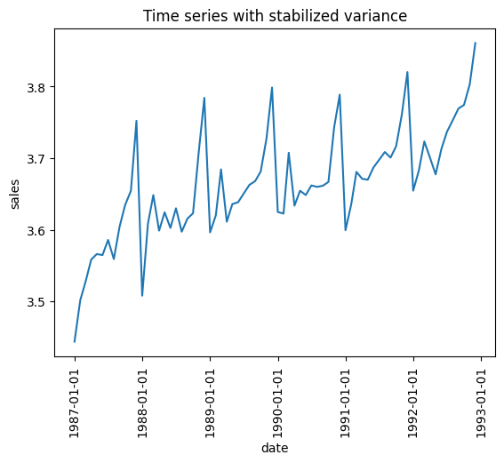

```python
fig, ax = plt.subplots()
ax.plot(tseries_novar["sales"])
ax.set_title("Time series with stabilized variance")
ax.set_xlabel("date")
ax.set_ylabel("sales")
ax.set_xticks(ax.get_xticks()[1::1])
plt.xticks(rotation = 90)
plt.show()
```

```python
tseries_diff = tseries_novar.copy(deep = True)
tseries_diff["sales"] = tseries_diff["sales"].diff(periods = 1)
tseries_diff = tseries_diff.iloc[1:]
tseries_diff
```

| date | sales |
| --- | --- |
| 1987-02-01 | 0.057891 |
| 1987-03-01 | 0.025229 |
| 1987-04-01 | 0.031510 |
| 1987-05-01 | 0.007729 |
| 1987-06-01 | -0.001396 |
| ... | ... |
| 1992-08-01 | 0.016046 |
| 1992-09-01 | 0.016463 |
| 1992-10-01 | 0.005105 |
| 1992-11-01 | 0.028748 |
| 1992-12-01 | 0.057713 |

71 rows × 1 columns

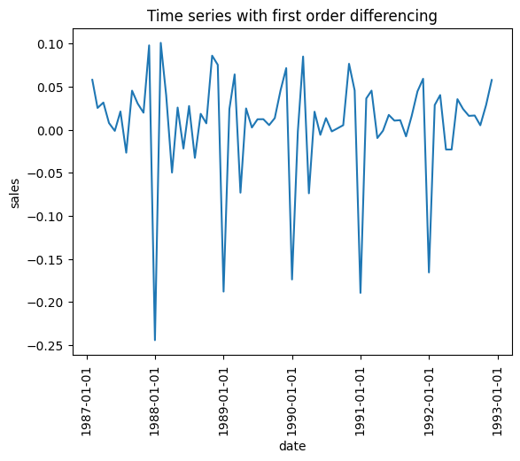

```python
fig, ax = plt.subplots()
ax.plot(tseries_diff["sales"])
ax.set_title("Time series with first order differencing")
ax.set_xlabel("date")
ax.set_ylabel("sales")
ax.set_xticks(ax.get_xticks()[1::1])
plt.xticks(rotation = 90)
plt.show()
```

The first order differencing removes trend, but leaves seasonality.

```python
tseries_diff_s = tseries_novar.copy(deep = True)
tseries_diff_s["sales"] = tseries_diff_s["sales"].diff(periods = 12)
tseries_diff_s = tseries_diff_s.iloc[12:]
tseries_diff_s
```

| date | sales |
| --- | --- |
| 1988-01-01 | 0.064202 |
| 1988-02-01 | 0.107133 |
| 1988-03-01 | 0.121736 |
| 1988-04-01 | 0.040426 |
| 1988-05-01 | 0.058380 |
| 1988-06-01 | 0.037900 |
| 1988-07-01 | 0.044232 |
| 1988-08-01 | 0.038239 |
| 1988-09-01 | 0.011337 |
| 1988-10-01 | -0.011622 |
| 1988-11-01 | 0.054617 |
| 1988-12-01 | 0.032061 |
| 1989-01-01 | 0.088451 |
| 1989-02-01 | 0.011526 |
| 1989-03-01 | 0.035867 |
| 1989-04-01 | 0.012516 |
| 1989-05-01 | 0.011527 |
| 1989-06-01 | 0.035912 |
| 1989-07-01 | 0.020505 |
| 1989-08-01 | 0.065412 |
| 1989-09-01 | 0.052333 |
| 1989-10-01 | 0.058421 |
| 1989-11-01 | 0.018319 |
| 1989-12-01 | 0.014419 |
| 1990-01-01 | 0.028504 |
| 1990-02-01 | 0.002387 |
| 1990-03-01 | 0.023147 |
| 1990-04-01 | 0.022415 |
| 1990-05-01 | 0.018570 |
| 1990-06-01 | 0.010074 |
| 1990-07-01 | 0.011416 |
| 1990-08-01 | -0.002764 |
| 1990-09-01 | -0.006471 |
| 1990-10-01 | -0.014722 |
| 1990-11-01 | 0.015944 |
| 1990-12-01 | -0.009979 |
| 1991-01-01 | -0.025552 |
| 1991-02-01 | 0.012920 |
| 1991-03-01 | -0.026660 |
| 1991-04-01 | 0.037513 |
| 1991-05-01 | 0.015415 |
| 1991-06-01 | 0.038552 |
| 1991-07-01 | 0.035647 |
| 1991-08-01 | 0.048681 |
| 1991-09-01 | 0.039313 |
| 1991-10-01 | 0.049992 |
| 1991-11-01 | 0.017970 |
| 1991-12-01 | 0.031579 |
| 1992-01-01 | 0.055320 |
| 1992-02-01 | 0.047692 |
| 1992-03-01 | 0.042533 |
| 1992-04-01 | 0.029227 |
| 1992-05-01 | 0.007447 |
| 1992-06-01 | 0.025719 |
| 1992-07-01 | 0.039269 |
| 1992-08-01 | 0.044277 |
| 1992-09-01 | 0.068504 |
| 1992-10-01 | 0.057723 |
| 1992-11-01 | 0.041973 |
| 1992-12-01 | 0.040557 |

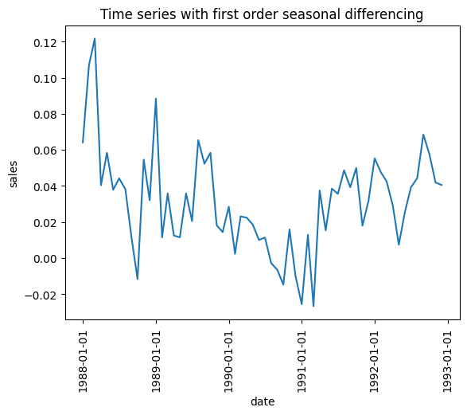

```python
fig, ax = plt.subplots()
ax.plot(tseries_diff_s["sales"])
ax.set_title("Time series with first order seasonal differencing")
ax.set_xlabel("date")
ax.set_ylabel("sales")
ax.set_xticks(ax.get_xticks()[1::1])
plt.xticks(rotation = 90)
plt.show()
```

The seasonal differencing removes seasonality, but leaves trend.

```python
tseries_diff_final = tseries_novar.copy(deep = True)
tseries_diff_final["sales"] = tseries_diff_final["sales"].diff(periods = 1).diff(periods = 12)
tseries_diff_final = tseries_diff_final.iloc[13:]
tseries_diff_final
```

| date | sales |
| --- | --- |
| 1988-02-01 | 0.042931 |
| 1988-03-01 | 0.014603 |
| 1988-04-01 | -0.081310 |
| 1988-05-01 | 0.017954 |
| 1988-06-01 | -0.020480 |
| 1988-07-01 | 0.006332 |
| 1988-08-01 | -0.005994 |
| 1988-09-01 | -0.026901 |
| 1988-10-01 | -0.022960 |
| 1988-11-01 | 0.066239 |
| 1988-12-01 | -0.022556 |
| 1989-01-01 | 0.056390 |
| 1989-02-01 | -0.076924 |
| 1989-03-01 | 0.024341 |
| 1989-04-01 | -0.023351 |
| 1989-05-01 | -0.000989 |
| 1989-06-01 | 0.024385 |
| 1989-07-01 | -0.015407 |
| 1989-08-01 | 0.044907 |
| 1989-09-01 | -0.013079 |
| 1989-10-01 | 0.006088 |
| 1989-11-01 | -0.040102 |
| 1989-12-01 | -0.003900 |
| 1990-01-01 | 0.014085 |
| 1990-02-01 | -0.026117 |
| 1990-03-01 | 0.020760 |
| 1990-04-01 | -0.000732 |
| 1990-05-01 | -0.003845 |
| 1990-06-01 | -0.008495 |
| 1990-07-01 | 0.001341 |
| 1990-08-01 | -0.014180 |
| 1990-09-01 | -0.003707 |
| 1990-10-01 | -0.008252 |
| 1990-11-01 | 0.030666 |
| 1990-12-01 | -0.025923 |
| 1991-01-01 | -0.015573 |
| 1991-02-01 | 0.038472 |
| 1991-03-01 | -0.039579 |
| 1991-04-01 | 0.064173 |
| 1991-05-01 | -0.022099 |
| 1991-06-01 | 0.023137 |
| 1991-07-01 | -0.002905 |
| 1991-08-01 | 0.013035 |
| 1991-09-01 | -0.009368 |
| 1991-10-01 | 0.010679 |
| 1991-11-01 | -0.032023 |
| 1991-12-01 | 0.013609 |
| 1992-01-01 | 0.023742 |
| 1992-02-01 | -0.007628 |
| 1992-03-01 | -0.005159 |
| 1992-04-01 | -0.013307 |
| 1992-05-01 | -0.021780 |
| 1992-06-01 | 0.018272 |
| 1992-07-01 | 0.013551 |
| 1992-08-01 | 0.005007 |
| 1992-09-01 | 0.024228 |
| 1992-10-01 | -0.010782 |
| 1992-11-01 | -0.015750 |
| 1992-12-01 | -0.001416 |

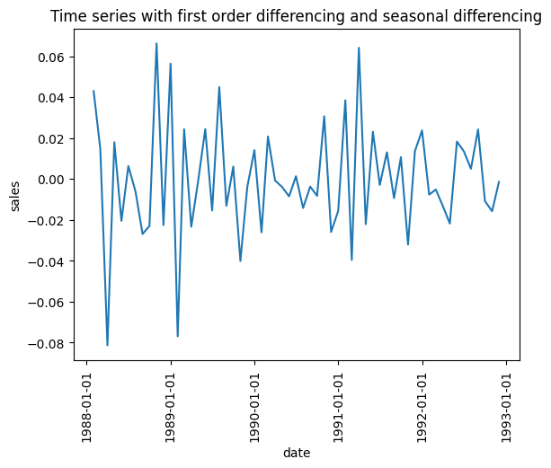

```python
fig, ax = plt.subplots()
ax.plot(tseries_diff_final["sales"])
ax.set_title("Time series with first order differencing and seasonal differencing")
ax.set_xlabel("date")
ax.set_ylabel("sales")
ax.set_xticks(ax.get_xticks()[1::1])
plt.xticks(rotation = 90)
plt.show()
```

The new series should be stationary now. Let's check with our two tests.

```python
adfuller(tseries_diff_final["sales"])
```

```
(-5.903726178997968,
 2.73961678960973e-07,
 3,
 55,
 {'1%': -3.5552728880540942,
  '5%': -2.9157312396694217,
  '10%': -2.5956695041322315},
 -234.49533536833405)
```

```python
kpss(tseries_diff_final["sales"])
```

```
(0.02613487681632163,
 0.1,
 0,
 {'10%': 0.347, '5%': 0.463, '2.5%': 0.574, '1%': 0.739})
```

Our conclusions on the null hypothesis have now switched, as we expected.

Let's look at the ACF and PACF.

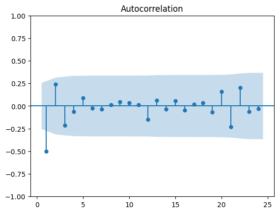

```python
plot_acf(tseries_diff_final["sales"], lags = 24, zero = False);
```

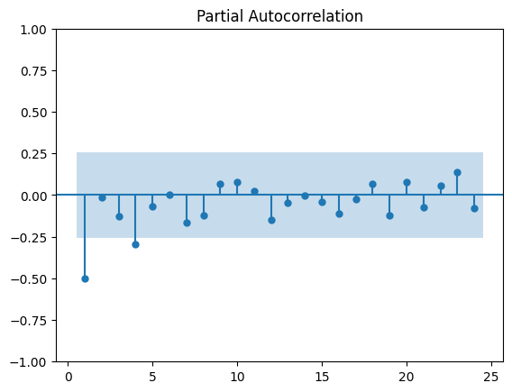

```python
plot_pacf(tseries_diff_final["sales"], lags = 24, zero = False, method = "ywm");
```

## Estimate ARIMA model

At this point, we should be able to estimate the values for the parameters of our ARIMA model by looking at these two plots and the spikes in them. However, the most reliable way to actually determine the parameters is using an objective procedure, for example a stepwise-like, and let a computer do it for us by choosing among many ARIMA models the "best" one, in terms of optimizing a certain indicator.

```python
fit = pm.auto_arima(tseries_novar, start_p = 1, start_q = 1, max_p = 3, max_q = 3, m = 12,
                             start_P = 0, seasonal = True, d = 1, D = 1, trace = True,
                             error_action = "ignore",
                             suppress_warnings = True,
                             stepwise = True)
fit.summary()
```

```
Performing stepwise search to minimize aic
 ARIMA(1,1,1)(0,1,1)[12]             : AIC=-269.383, Time=1.02 sec
 ARIMA(0,1,0)(0,1,0)[12]             : AIC=-251.964, Time=0.04 sec
 ARIMA(1,1,0)(1,1,0)[12]             : AIC=-269.841, Time=0.68 sec
 ARIMA(0,1,1)(0,1,1)[12]             : AIC=-269.740, Time=0.42 sec
 ARIMA(1,1,0)(0,1,0)[12]             : AIC=-267.544, Time=0.07 sec
 ARIMA(1,1,0)(2,1,0)[12]             : AIC=-268.583, Time=0.43 sec
 ARIMA(1,1,0)(1,1,1)[12]             : AIC=-269.956, Time=0.56 sec
 ARIMA(1,1,0)(0,1,1)[12]             : AIC=-271.244, Time=0.22 sec
 ARIMA(1,1,0)(0,1,2)[12]             : AIC=-269.821, Time=0.67 sec
 ARIMA(1,1,0)(1,1,2)[12]             : AIC=-267.700, Time=1.65 sec
 ARIMA(0,1,0)(0,1,1)[12]             : AIC=-252.302, Time=0.38 sec
 ARIMA(2,1,0)(0,1,1)[12]             : AIC=-269.369, Time=0.81 sec
 ARIMA(2,1,1)(0,1,1)[12]             : AIC=-267.667, Time=1.18 sec
 ARIMA(1,1,0)(0,1,1)[12] intercept   : AIC=-269.622, Time=0.45 sec

Best model:  ARIMA(1,1,0)(0,1,1)[12]
Total fit time: 8.612 seconds
```

SARIMAX Results

| Dep. Variable: | y | No. Observations: | 72 |
| --- | --- | --- | --- |
| Model: | SARIMAX(1, 1, 0)x(0, 1, [1], 12) | Log Likelihood | 138.622 |
| Date: | Thu, 04 May 2023 | AIC | -271.244 |
| Time: | 21:22:09 | BIC | -265.011 |
| Sample: | 01-01-1987 | HQIC | -268.811 |
|  | - 12-01-1992 |  |  |
| Covariance Type: | opg |  |  |

|  | coef | std err | z | P>\|z\| | [0.025 | 0.975] |
| --- | --- | --- | --- | --- | --- | --- |
| ar.L1 | -0.5521 | 0.124 | -4.442 | 0.000 | -0.796 | -0.308 |
| ma.S.L12 | -0.4516 | 0.181 | -2.493 | 0.013 | -0.807 | -0.097 |
| sigma2 | 0.0005 | 0.000 | 4.347 | 0.000 | 0.000 | 0.001 |

| Ljung-Box (L1) (Q): | 0.00 | Jarque-Bera (JB): | 0.02 |
| --- | --- | --- | --- |
| Prob(Q): | 0.99 | Prob(JB): | 0.99 |
| Heteroskedasticity (H): | 0.30 | Skew: | -0.04 |
| Prob(H) (two-sided): | 0.01 | Kurtosis: | 2.95 |

Warnings:  
[1] Covariance matrix calculated using the outer product of gradients (complex-step).

The chosen model appears to be *ARIMA(1,1,0)(0,1,1)[12]*. Along with it, we have also got a number of diagnostic tools: we can see that the parameters are significantly different than 0, while none of the residuals is significant.

Let's look at other diagnostic measures through some plots.

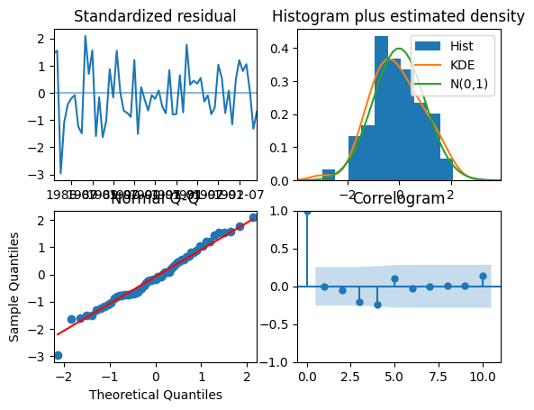

```python
fit.plot_diagnostics();
```

## Forecast

For the last step, let's try to forecast some future values, in particular 12 more observations, and plot the result.

```python
forecast = fit.predict(n_periods = 12)
df_forecast = pd.DataFrame({"sales": forecast.values})
df_forecast["sales"] = inv_boxcox(df_forecast["sales"], lmbda)
df_forecast.set_index(forecast.index, inplace = True)
df_forecast.index.name = "date"
tseries_forecast = pd.concat([tseries, df_forecast])
tseries_forecast
```

| date | sales |
| --- | --- |
| 1987-01-01 | 1664.810000 |
| 1987-02-01 | 2397.530000 |
| 1987-03-01 | 2840.710000 |
| 1987-04-01 | 3547.290000 |
| 1987-05-01 | 3752.960000 |
| ... | ... |
| 1993-08-01 | 26288.574310 |
| 1993-09-01 | 29161.143853 |
| 1993-10-01 | 32410.080979 |
| 1993-11-01 | 55069.265169 |
| 1993-12-01 | 137764.601875 |

84 rows × 1 columns

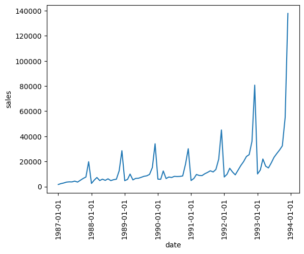

```python
fig, ax = plt.subplots()
ax.plot(tseries_forecast["sales"])
ax.set_xlabel("date")
ax.set_ylabel("sales")
ax.set_xticks(ax.get_xticks()[1::1])
plt.xticks(rotation = 90)
plt.show()
```